# Homework 2

2022-10-10

Question 1: Add age to the data set. Age is calculated as the number of rings plus 1.5 Assess and describe the distribution of age

```r
library(tidyverse)
library(tidymodels)
abalone_data<-read.csv("/Users/kassandratrejo/Desktop/131-Homeworks/abalone.csv")
```

```r
abalone_data$age<-abalone_data$rings + 1.5
```

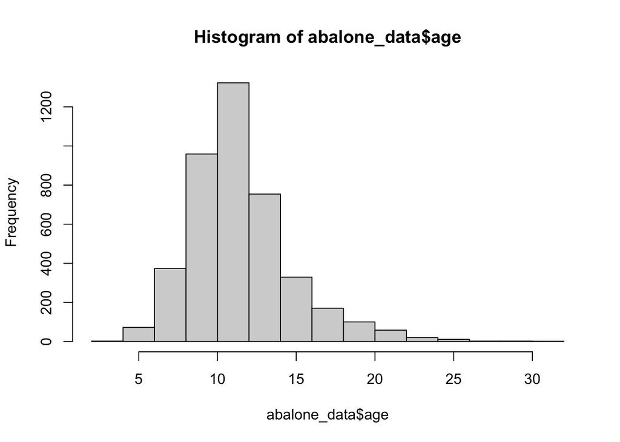

```r
hist(abalone_data$age)
```

```r
summary(abalone_data$age)
```

```
##    Min. 1st Qu.  Median    Mean 3rd Qu.    Max.
##    2.50    9.50   10.50   11.43   12.50   30.50
```

Looking at a histogram of the variable age, we can see that it is slightly right skewed and the mean of age is 11.43.With the median age of 10.50, since the data is skewed this would be a better measure of the data.

Question 2: Split the data into a training set and a testing set. use stratified sampling. you should decide on appropriate percentages for splitting the data

```r
set.seed(434)
abalone_split<- initial_split(abalone_data, prop= 0.80, strata= age)
abalone_train <-training(abalone_split)
abalone_test <-testing(abalone_split)
```

Question 3: using training data, create a recipe predicting the outcome variable, age, with all other predictor variables. Should not include rings to predict age. Explain why you shouldn’t use rings to predict age. Steps for recipe: 1. dummy code categorical predictors. 2. create interactions between type and shucked_weight, longest_shell and diameter, shucked_weight and shell_weight 3. center all predictors 4. scale all predictors.

You shouldn’t use rings to predict age because rings was already used ot generate age. Rings is a function of age and therefore if used in the model it will give us a false estimate or our predictors.

```r
abalone_recipe<- recipe(age~., data= abalone_train) %>%
  step_rm(rings) %>%
  step_dummy(all_nominal_predictors()) %>%
  step_interact(terms= ~starts_with("type"):shucked_weight + longest_shell:diameter+
                  shucked_weight:shell_weight) %>%
  step_normalize(all_predictors())
```

Question 4: create and store a linear regression object using the “lm” engine

```r
lm_model <- linear_reg() %>%
  set_engine("lm")
```

Question 5: 1. set up an empty workflow 2. add the model created in question 4 3. add the recipe created in question 3

```r
lm_wflow <- workflow() %>%
  add_model(lm_model) %>%
  add_recipe(abalone_recipe)
```

Question 6: Use your fit() object to predict the age of a hypothetical female abalone with longest_shell = 0.50, diameter = 0.10, height = 0.30, whole_weight = 4, shucked_weight = 1, viscera_weight = 2, shell_weight = 1.

```r
lm_fit <- fit(lm_wflow, abalone_train)
predict(lm_fit,new_data=data.frame(type='F',longest_shell=0.50,diameter=0.10,height=0.30,whole_weight=4,
                                  shucked_weight=1, viscera_weight=2,shell_weight=1,rings=9))
```

```
## # A tibble: 1 × 1
##   .pred
##   <dbl>
## 1  22.3
```

The predicted age of a hypothetical female abalone with the above specifications is 22.349.

Question 7: 1. create a metric set that includes R2, RMSE (root mean squared error), and MAE (mean absolute error). 2. Use predict() and bind_cols() to create a tibble of your model’s predicted values from the training data along with the actual observed ages (these are needed to assess your model’s performance). 3. Finally, apply your metric set to the tibble, report the results, and interpret the R2 value.

```r
abalone_train_res<-predict(lm_fit, new_data=abalone_train %>% select(-age))
abalone_train_res
```

```
## # A tibble: 3,340 × 1
##    .pred
##    <dbl>
##  1  9.23
##  2  9.60
##  3 10.3
##  4  9.92
##  5 10.8
##  6  6.14
##  7  5.86
##  8  5.94
##  9  8.49
## 10 11.8
## # … with 3,330 more rows
```

```r
abalone_train_res<-bind_cols(abalone_train_res, abalone_train %>% select(age))
abalone_train_res
```

```
## # A tibble: 3,340 × 2
##    .pred   age
##    <dbl> <dbl>
##  1  9.23   9.5
##  2  9.60   8.5
##  3 10.3    8.5
##  4  9.92   9.5
##  5 10.8    9.5
##  6  6.14   6.5
##  7  5.86   6.5
##  8  5.94   5.5
##  9  8.49   8.5
## 10 11.8    8.5
## # … with 3,330 more rows
```

```r
abalone_metrics <- metric_set(rmse, rsq, mae)
abalone_metrics(abalone_train_res, truth = age,
                estimate = .pred)
```

```
## # A tibble: 3 × 3
##   .metric .estimator .estimate
##   <chr>   <chr>          <dbl>
## 1 rmse    standard       2.16
## 2 rsq     standard       0.558
## 3 mae     standard       1.55
```

The R2 value is 0.558. This means that 0.558 of the variability in Y can be explained using X. The RSE is an absolute measure of lack of fit, or the standard deviation of the residuals. Our RSE value is 2.1602. The MAE value is 1.545. MAE can be interpreted as the average error that the model’s predictions have compared to the actual value.